# Homework 16

Alan Vongsavanh

2026-03-06

## Instructions

Answer the following questions and complete the exercises in RMarkdown. Please embed all of your code and push your final work to your repository. Your final lab report should be organized, clean, and run free from errors. Remember, you must remove the `#` for the included code chunks to run. Be sure to add your name to the author header above. For any included plots, make sure they are clearly labeled. You are free to use any plot type that you feel best communicates the results of your analysis.

Make sure to use the formatting conventions of RMarkdown to make your report neat and clean!

### Install Biostrings

```r
#if (!requireNamespace("BiocManager", quietly = TRUE))
#  install.packages("BiocManager")

BiocManager::install("Biostrings")
```

## Load the libraries

```r
library(tidyverse)
library(janitor)
library(dplyr)
library(readr)
library(Biostrings)
```

```r
options(scipen = 999)
```

## Background

A patient has been admitted to the hospital with a severe and rapidly progressing bacterial infection of unknown origin. Standard clinical cultures have been inconclusive. As part of the diagnostic workup, RNA was extracted directly from the patient’s tissue sample and submitted for RNA sequencing (RNA-seq). From this sequencing data, you have successfully assembled the complete coding sequence of a gene expressed by the infecting bacterium. You will use BLAST, a tool used in real clinical and research microbiology labs, to compare this unknown sequence against all known biological sequences in the NCBI database.

**1. Read the “gene of interest” sequence from the `goi_01.txt` file into R using the Biostrings package. Store this in an object called `query_seq`.What type sequence is this? (DNA, RNA or Protein)**

```r
#skip this problem - Bry
```

**2.Perform a blastx search using `goi_01.txt` as the query and the “core_nt” database. Download the cluster table results in CSV format, change the name to “goi_01_blastx.csv” and store in the homework/data folder. Read the csv file into R and clean the column names. Save the cleaned data frame as goi_01_blastx.**

```r
goi_01_blastx <- read_csv("data/goi_01_blastx.csv") %>%
  clean_names()
goi_01_blastx
```

```
## # A tibble: 100 × 12
##    cluster_composition   cluster_ancestor representative_seque…¹ scientific_name
##    <chr>                 <chr>            <chr>                  <chr>
##  1 8 member(s) 4 organi… enterobacteria   minor capsid protein,… Enterobacteral…
##  2 11 member(s) 6 organ… enterobacteria   minor capsid protein … Enterobacteria…
##  3 91 member(s) 31 orga… root             minor capsid protein … root
##  4 61 member(s) 17 orga… enterobacteria   minor capsid protein … Salmonella
##  5 4 member(s) 3 organi… bacteria         minor capsid protein,… Bacteria
##  6 1 member(s) 1 organi… CDC Enteric Gro… hypothetical protein … Enterobacter h…
##  7 1 member(s) 1 organi… enterobacteria   minor capsid protein … Buttiauxella s…
##  8 1 member(s) 1 organi… enterobacteria   minor capsid protein … Escherichia fe…
##  9 3 member(s) 1 organi… E. coli          minor capsid protein … Escherichia co…
## 10 7 member(s) 4 organi… enterobacteria   minor capsid protein … Enterobacteria…
## # ℹ 90 more rows
## # ℹ abbreviated name: ¹representative_sequence
## # ℹ 8 more variables: taxid <dbl>, max_score <dbl>, total_score <dbl>,
## #   query_cover <chr>, e_value <dbl>, per_ident <dbl>, acc_len <dbl>,
## #   accession <chr>
```

**3.Display the top 10 blastx hits, based on e_value, for this blastx search? (Include the Scientific Name, Cluster Anscestor, Cluster Representative Sequence, Max Score, Query Cover, E value and Percent Identity)**

```r
top10_blastx <- goi_01_blastx %>%
  slice_min(e_value, n = 10) %>%
  select(scientific_name, cluster_ancestor, representative_sequence, max_score, query_cover, e_value, per_ident)
top10_blastx
```

```
## # A tibble: 10 × 7
##    scientific_name cluster_ancestor representative_seque…¹ max_score query_cover
##    <chr>           <chr>            <chr>                      <dbl> <chr>
##  1 Enterobacteral… enterobacteria   minor capsid protein,…       215 81%
##  2 Enterobacteria… enterobacteria   minor capsid protein …       211 99%
##  3 root            root             minor capsid protein …       210 99%
##  4 Salmonella      enterobacteria   minor capsid protein …       196 99%
##  5 Bacteria        bacteria         minor capsid protein,…       194 74%
##  6 Enterobacter h… CDC Enteric Gro… hypothetical protein …       192 99%
##  7 Buttiauxella s… enterobacteria   minor capsid protein …       192 99%
##  8 Escherichia fe… enterobacteria   minor capsid protein …       190 99%
##  9 Escherichia co… E. coli          minor capsid protein …       185 99%
## 10 Enterobacteria… enterobacteria   minor capsid protein …       184 99%
## # ℹ abbreviated name: ¹representative_sequence
## # ℹ 2 more variables: e_value <dbl>, per_ident <dbl>
```

**4. create a plot that shows the different in percent identity for each Scientific Name of the top 10 blastx hits. Make sure to label your axes and give your plot a title.**

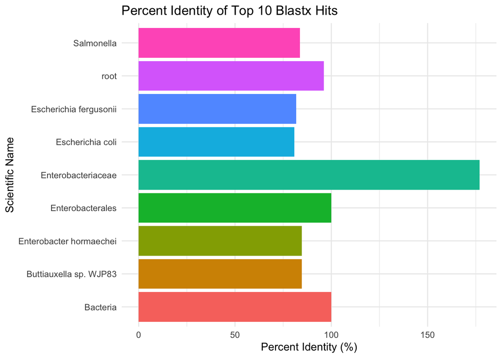

```r
top10_blastx %>%
  ggplot(aes(x = scientific_name, y = per_ident, fill = scientific_name)) +
  geom_col() +
  coord_flip() +
  labs(title = "Percent Identity of Top 10 Blastx Hits",
       x = "Scientific Name",
       y = "Percent Identity (%)") +
  theme_minimal() +
  theme(legend.position = "none")
```

**5 Perform a blastn search using `goi_01.txt` as the query and the “core_nt” database. Download the alignment description in CSV format, change the name to “goi_01_blastn.csv” and store in the homework/data folder. Read the csv file into R and clean the column names. Save the cleaned data frame as goi_01_blastn.**

```r
goi_01_blastn <- read_csv("data/goi_01_blastn.csv") %>%
  clean_names()
goi_01_blastn
```

```
## # A tibble: 100 × 11
##    description           scientific_name common_name taxid max_score total_score
##    <chr>                 <chr>           <lgl>       <dbl>     <dbl>       <dbl>
##  1 Yersinia pestis stra… Yersinia pestis NA            632       688         688
##  2 Yersinia pestis stra… Yersinia pestis NA            632       688         688
##  3 Yersinia pestis stra… Yersinia pestis NA            632       688         688
##  4 Yersinia pestis stra… Yersinia pestis NA            632       688         688
##  5 Yersinia pestis stra… Yersinia pestis NA            632       688         688
##  6 Yersinia pestis stra… Yersinia pestis NA            632       688         688
##  7 Yersinia pestis stra… Yersinia pestis NA            632       688         688
##  8 Yersinia pestis stra… Yersinia pestis NA            632       688         688
##  9 Yersinia pestis stra… Yersinia pestis NA            632       688         688
## 10 Yersinia pestis stra… Yersinia pestis NA            632       688         688
## # ℹ 90 more rows
## # ℹ 5 more variables: query_cover <chr>, e_value <dbl>, per_ident <dbl>,
## #   acc_len <dbl>, accession <chr>
```

**6. What was the top blastn hit, based on e_value, for this blastn search? (Include the Cluster Ancestor, Cluster, Representative Sequence, Max Score, Query Cover, E value, Percent Identity and Accession Link)**

```r
top1_blastn <- goi_01_blastn %>%
  slice_min(e_value, n = 1) #%>%
top1_blastn
```

```
## # A tibble: 100 × 11
##    description           scientific_name common_name taxid max_score total_score
##    <chr>                 <chr>           <lgl>       <dbl>     <dbl>       <dbl>
##  1 Yersinia pestis stra… Yersinia pestis NA            632       688         688
##  2 Yersinia pestis stra… Yersinia pestis NA            632       688         688
##  3 Yersinia pestis stra… Yersinia pestis NA            632       688         688
##  4 Yersinia pestis stra… Yersinia pestis NA            632       688         688
##  5 Yersinia pestis stra… Yersinia pestis NA            632       688         688
##  6 Yersinia pestis stra… Yersinia pestis NA            632       688         688
##  7 Yersinia pestis stra… Yersinia pestis NA            632       688         688
##  8 Yersinia pestis stra… Yersinia pestis NA            632       688         688
##  9 Yersinia pestis stra… Yersinia pestis NA            632       688         688
## 10 Yersinia pestis stra… Yersinia pestis NA            632       688         688
## # ℹ 90 more rows
## # ℹ 5 more variables: query_cover <chr>, e_value <dbl>, per_ident <dbl>,
## #   acc_len <dbl>, accession <chr>
```

```r
goi_01_blastx %>%
  filter(scientific_name == "Yersinia pestis") %>% #from blastn data, Yersinia pestis species was the top hit
  slice_max(e_value, n = 1) %>%
  select(cluster_ancestor, cluster_composition, representative_sequence, max_score, query_cover, e_value, per_ident, accession)
```

```
## # A tibble: 1 × 8
##   cluster_ancestor cluster_composition       representative_sequence   max_score
##   <chr>            <chr>                     <chr>                         <dbl>
## 1 enterobacteria   1 member(s) 1 organism(s) minor capsid protein, pa…       133
## # ℹ 4 more variables: query_cover <chr>, e_value <dbl>, per_ident <dbl>,
## #   accession <chr>
```

**7. Based on the blastx and blastn results, what do you think this gene is and what bacteria do you think it came from?**

```
This gene is the minor capsid protein, and the bacteria that this gene came from is the Yersinia pestis as showcased by its mention.
```

**8. For the top blastn hit, click on the accession link for this bacteria and download the coding sequences as a FASTA Protein file. Read the fasta file into R using the Biostrings package and store it in an object called `goi_blastn_hit`.**

```r
goi_blastn_hit <- readAAStringSet("data/sequence.fasta")
```

```r
goi_blastn_hit
```

```
## AAStringSet object of length 1:
##     width seq                                               names
## [1] 96210 ATGAAGGCTCTGATGGTCAGAAC...GAAAACCAGAAAGGTAAAAACAC CP177713.1 Yersin...
```

**9. From the same organism, identify 5 other annotated genes? Do these genes suggest about the biology or virulence of this bacterium?** *Annotated genes can be found in the “CDS” section of the GenBank file. You can also find genes by going to summary page for the organism and looking at the “View annotated genes” section.*

```r
genes <- read_tsv("data/ncbi_dataset.tsv") %>%
  clean_names
genes
```

```
## # A tibble: 10 × 13
##    accession   begin   end chromosome orientation name  symbol gene_id gene_type
##    <chr>       <dbl> <dbl> <lgl>      <chr>       <chr> <chr>    <dbl> <chr>
##  1 NZ_ADQO010…    77   568 NA         minus       Hcp … <NA>         0 protein-…
##  2 NZ_ADQO010…   572  2308 NA         minus       OmpA… <NA>         0 protein-…
##  3 NZ_ADQO010…  2308  2994 NA         minus       type… tssL         0 protein-…
##  4 NZ_ADQO010…  2991  3164 NA         minus       type… tssK         0 protein-…
##  5 NZ_ADQO010…   934  1599 NA         minus       ABC … <NA>         0 protein-…
##  6 NZ_ADQO010…    66  1763 NA         minus       C4-d… dauA         0 protein-…
##  7 NZ_ADQO010…   114  1172 NA         minus       glyc… <NA>         0 protein-…
##  8 NZ_ADQO010…  1188  1375 NA         minus       SDR … <NA>         0 protein-…
##  9 NZ_ADQO010…   554  1729 NA         plus        volt… kch          0 protein-…
## 10 NZ_ADQO010…  1827  2231 NA         minus       fluo… crcB         0 protein-…
## # ℹ 4 more variables: transcripts_accession <lgl>, protein_accession <chr>,
## #   protein_length <dbl>, locus_tag <chr>
```

These genes suggest that this bacterium is related to toxin delivery, secretion, and/or transport, affecting other cells to maintain its own survival.

**10. Now that you have an idea of this bacteria’s identity, what illness/disease do you think the patient has? What is the historical or public health significance of this disease? Based on the gene you identified, what role might this gene play in pathogenicity?**

```
I think the patient has the Plague, as there are ties to this disease from the bacterium that the patient has. This disease has historically decimated the human population in the past before with an immense mortality rate, and was an immnense health concern. This gene alone probably works to spread toxins and other genes across the body to spread the influence of the virus/bacterium.
```

## Knit and Upload

Please knit your work as an .html file and upload to Canvas. Homework is due before the start of the next lab. No late work is accepted. Make sure to use the formatting conventions of RMarkdown to make your report neat and clean!